2017 Edition

In this notebook, we will learn how to use the DataFrame API and SparkSQL to perform simple data analytics tasks.

# Goals

The main goals of this notebook are the following:

1. Understand the advantages and disadvantages of using DataFrame over RDD
2. Analyze the airline data with the DataFrame API and SparkSQL

# Steps

- First, in section 1, we will go through a short introduction about the DataFrame API with a small example to see how can we use it and how it compares to the low-level RDD abstraction.
- In section 2, we delve into the details of the use case of this notebook including: providing the context, introducing the data
- In section 3, we perform data exploration and analysis

# 1. RDD and DataFrame APIs

In our previous notebooks, we have worked with RDDs (Resilient Distributed Dataset), the basic abstraction in Spark. The main reason is due to the task at hand: we have been invovled in the design of distributed algorithms.

In this laboratory session, we study (or revisit) the DataFrame API - an immutable distributed collection of data. DataFrames allow developers to impose a **structure** on a distributed collection of data, allowing higher-level abstraction; in addition, DataFrames provide a domain specific language (DSL) API to manipulate distributed, structured data. Ultimately, the goal is to make Spark accessible to a wider audience, beyond researchers and specialized data engineers.

Let's take a small example to see the difference between RDDs and DataFrames. The two cells below contain short code snippets that perform the same task: count the frequency of words in a document, then sort the result in descending order. The first snippet is the same you have been working on in the very [first notebook](https://github.com/EURECOM-CLOUDS-COURSE/Introduction/blob/master/introduction-lab.ipynb) of the CLOUDS course. The second code snippet uses the DataFrame API.

**Question 1.** Run both approaches (RDD and DataFrame) detailed below, compare their runtime, and discuss. Is the DataFrame API approach faster? Can you explain why?

The RDD approach is much more slower than the DataFrame approach: 301.53s vs 148.94s We can explain that by the fact that an RDD (Resilient Distributed Dataset) is like a box of data that cannot be optimized as the operations that can be performed against it, are not as constrained.  
On the other hand, a dateframe is, by definition, a table, or two-dimensional array-like structure, in which each column contains measurements on one variable, and each row contains one case. So, it has additional metadata due to its tabular format, which allows Spark to run certain optimizations on the finalized query.

**Therefore, in this case, since we're dealing with a structered dataset, it's better to use a dataframe and that was proven by this example.**

```python
import time
time_start = time.time()
words = (
            # read the text file
            sc.textFile("/datasets/gutenberg/gutenberg_small.txt").repartition(16)

            # construct words from lines
            .flatMap(lambda line: line.split())

            # map each word to (word, 1)
            .map(lambda x: (x, 1))

            # reduce by key: accumulate sum the freq of the same word
            .reduceByKey(lambda freq1, freq2: freq1 + freq2)

            # swap (word, freq) to (freq, word)
            .map(lambda x: (x[1], x[0]))

            # sort result by key DESC
            .sortByKey(False)
         )
print("Runtime: {}s".format(time.time() - time_start))
print(words.take(5))
```

```
Runtime: 301.5307037830353s
[(29556020, 'the'), (18043957, 'of'), (14914748, 'and'), (12892052, 'to'), (9779124, 'a')]
```

```python
from pyspark.sql.types import *
from pyspark.sql import SQLContext
from pyspark.sql.functions import explode, split, desc
sqlContext = SQLContext(sc)
time_start = time.time()

# read the text file
df = sqlContext.read.text("/datasets/gutenberg/gutenberg_small.txt")

# show 3 samples
df.show(3)

result = (
    # split into words
    df.select(explode(split(df.value, "\s+|\t+")).alias('word'))

    # group by each word
    .groupBy(['word'])

    # count the freq
    .count()

    # sort the result
    .orderBy(desc("count"))
)

result.show(5)
print("Runtime: {}s".format(time.time() - time_start))
```

```
+--------------------+
|               value|
+--------------------+
|Project Gutenberg...|
|This is our 3rd e...|
|                    |
+--------------------+
only showing top 3 rows

+----+--------+
|word|   count|
+----+--------+
| the|29556020|
|  of|18043957|
|    |16611988|
| and|14914748|
|  to|12892052|
+----+--------+
only showing top 5 rows

Runtime: 148.9457564353943s
```

# 2. Analysis of flight data using the DataFrame API and SparkSQL

## Use case

In this notebook, we play the role of a data scientist working in the travel industry, specifically on air transportation of passengers. We want to explore the data collected by the Department of Transportation (DoT) to understand passengers' behavior, as well as the properties of all flights, across several airline companies.

The dataset provided by the DoT has 29 features, that can be either categorical or numerical. For example, the `src_airport` (source airport) is categorical: there exist no comparison operator between airport names. We can not say "SGN is bigger than NCE". The `departure_time` feature is numerical, for which a comparison operator exists. For instance, "flight departing before 6PM" can be express by "departure_time < 1800".

In this use case, most features are numerical, except carrier, flight_number, cancelled, cancelation_code and diverted. The data contains a header, that is useless when analyzing the data: it serves the purpose of an "embedded schema", to help data scientist figure out what information is available. Note that there are some features with missing values in some lines of the dataset. The missing values are marked by "NA". These values can cause problems when processing the data and can lead to unexpected results. Therefore, we need to remove the header and replace all "NA" values by empty values, such as they can be interpreted as null values.

## DataFrame

As we have seen already, there are multiple ways to manipulate data:

- Using the RDD abstraction
- Using the DataFrame abstraction.

A DataFrame is a distributed collection of data organized into named columns. It is based on the data frame concept in R language or in Pandas for Python. In some sense, it is similar to a table in a relational database: each item is a list of values (the columns). Also, the value in each row of each column can be accessed by the column's name.

To use DataFrames, the data should be clean (no invalid values). That means we cannot create DataFrame directly from the "RAW" data. Instead, we will first create an RDD from RAW data, produce a new, clean RDD, then transform it to a DataFrame and work on it. The RDD `cleaned_data` is an RDD[String]. We need to transform it to RDD[(TypeOfColumn1, TypeOfColumn2, ..., TypeOfColumn29)] then call a function to create a DataFrame from the new RDD. Please note that, package com.databricks.spark.csv can really help us to load the data efficiently without concerns about parsing, conversions, etc... However, the CSV package can have some problems when loading not well-formatted data or the data that has many kinds of missing values. The guidelines defined this notebook are a general way to help you work with any data.

DataFrames can be constructed from a wide array of sources such as: structured data files, tables in Hive, external databases, or existing RDDs.

During the labs in this course, we will mainly work with CSV data files. So, in the next sections, we only focus on constructing dataframes from structured data files directly and from existing RDD.

### Constructing a DataFrame directly from structured data file

To construct DataFrame from a structured file directly, the file type must be supported. Currently, Spark supports csv, json, avro and many more. Among these types, the csv type is one of the most popular in data analytics. A DataFrame is constructed from csv files by using the package spark-csv from Databricks.

```python
from pyspark.sql import SQLContext
from pyspark.sql.types import *

sqlContext = SQLContext(sc)

df = sqlContext.read.load('/datasets/airline/1994.csv',
    format='com.databricks.spark.csv',
    header='true',
    inferSchema='true',
    nullValue='NA'
)
```

Using the function load parametrized with `com.databricks.spark.csv`, we ask the SqlContext to use the parser from the DataBricks package. Additionally, we can specify whether the file has a header, or ask the parser to guess the data type of columns automatically. The parsed data types is viewed using the function printSchema.

```python
print(df.dtypes)
df.printSchema()
```

```
[('Year', 'int'), ('Month', 'int'), ('DayofMonth', 'int'), ('DayOfWeek', 'int'), ('DepTime', 'int'), ('CRSDepTime', 'int'), ('ArrTime', 'int'), ('CRSArrTime', 'int'), ('UniqueCarrier', 'string'), ('FlightNum', 'int'), ('TailNum', 'string'), ('ActualElapsedTime', 'int'), ('CRSElapsedTime', 'int'), ('…
root
 |-- Year: integer (nullable = true)
 |-- Month: integer (nullable = true)
 |-- DayofMonth: integer (nullable = true)
 |-- DayOfWeek: integer (nullable = true)
 |-- DepTime: integer (nullable = true)
 |-- CRSDepTime: integer (nullable = true)
 |-- ArrTime: integer (nullable = true)
 |-- CRSArrTime: integer (nullable = true)
 |-- UniqueCarrier: string (nullable = true)
 |-- FlightNum: integer (nullable = true)
 |-- TailNum: string (nullable = true)
 |-- ActualElapsedTime: integer (nullable = true)
 |-- CRSElapsedTime: integer (nullable = true)
 |-- AirTime: string (nullable = true)
 |-- ArrDelay: integer (nullable = true)
 |-- DepDelay: integer (nullable = true)
 |-- Origin: string (nullable = true)
 |-- Dest: string (nullable = true)
 |-- Distance: integer (nullable = true)
 |-- TaxiIn: string (nullable = true)
 |-- TaxiOut: string (nullable = true)
 |-- Cancelled: integer (nullable = true)
 |-- CancellationCode: string (nullable = true)
 |-- Diverted: integer (nullable = true)
 |-- CarrierDelay: string (nullable = true)
 |-- WeatherDelay: string (nullable = true)
 |-- NASDelay: string (nullable = true)
 |-- SecurityDelay: string (nullable = true)
 |-- LateAircraftDelay: string (nullable = true)
```

```python
df = (df
          # change type of column CRSDepTime by casting its values to interger type
          .withColumn('CRSDepTime', df.CRSDepTime.cast('int'))

          # rename the column
          .withColumnRenamed('CRSDepTime', 'scheduled_departure_time')
    )

# print schema of the current data
df.printSchema()

# run jobs to calculate basic statistic information and show it
df.describe().show()
```

```
root
 |-- Year: integer (nullable = true)
 |-- Month: integer (nullable = true)
 |-- DayofMonth: integer (nullable = true)
 |-- DayOfWeek: integer (nullable = true)
 |-- DepTime: integer (nullable = true)
 |-- scheduled_departure_time: integer (nullable = true)
 |-- ArrTime: integer (nullable = true)
 |-- CRSArrTime: integer (nullable = true)
 |-- UniqueCarrier: string (nullable = true)
 |-- FlightNum: integer (nullable = true)
 |-- TailNum: string (nullable = true)
 |-- ActualElapsedTime: integer (nullable = true)
 |-- CRSElapsedTime: integer (nullable = true)
 |-- AirTime: string (nullable = true)
 |-- ArrDelay: integer (nullable = true)
 |-- DepDelay: integer (nullable = true)
 |-- Origin: string (nullable = true)
 |-- Dest: string (nullable = true)
 |-- Distance: integer (nullable = true)
 |-- TaxiIn: string (nullable = true)
 |-- TaxiOut: string (nullable = true)
 |-- Cancelled: integer (nullable = true)
 |-- CancellationCode: string (nullable = true)
 |-- Diverted: integer (nullable = true)
 |-- CarrierDelay: string (nullable = true)
 |-- WeatherDelay: string (nullable = true)
 |-- NASDelay: string (nullable = true)
 |-- SecurityDelay: string (nullable = true)
 |-- LateAircraftDelay: string (nullable = true)

+-------+--------------------+------------------+------------------+------------------+------------------+------------------------+------------------+-----------------+-------------+-----------------+-------+------------------+------------------+-------+-----------------+-----------------+-------+--…
|summary|                Year|             Month|        DayofMonth|         DayOfWeek|           DepTime|scheduled_departure_time|           ArrTime|       CRSArrTime|UniqueCarrier|        FlightNum|TailNum| ActualElapsedTime|    CRSElapsedTime|AirTime|         ArrDelay|         DepDelay| Origin|  …
+-------+--------------------+------------------+------------------+------------------+------------------+------------------------+------------------+-----------------+-------------+-----------------+-------+------------------+------------------+-------+-----------------+-----------------+-------+--…
|  count|             5180048|           5180048|           5180048|           5180048|           5113308|                 5180048|           5101202|          5180048|      5180048|          5180048|      0|           5101202|           5180048|      0|          5101202|          5113308|5180048|51…
|   mean|              1994.0| 6.579943853802127|15.723382486031017|3.9516016067804776| 1345.266130849149|      1338.6794068317513|1494.4365151585841|1495.874874904634|         null|920.2637743897354|   null|114.00258860558746|114.82526995888841|   null|5.662489742613603| 6.65992152242736|   null|  …
| stddev|7.992761522517662...|3.4367203739746874| 8.788272360339171|1.9902384397189954|470.22426611386055|        463.617501147721|483.98495590427785|472.6701494862189|         null| 608.134294392797|   null| 64.88861058427636| 64.20406191593854|   null|23.61815604081699|22.22629770848844|   null|  …
|    min|                1994|                 1|                 1|                 1|                 1|                       1|                 1|                1|           AA|                1|   null|               -40|                -5|   null|             -115|             -109|    ABE|  …
|    max|                1994|                12|                31|                 7|              2400|                    2400|              2400|             2400|           WN|             3599|   null|               740|               578|   null|             1313|             1439|    YAK|  …
+-------+--------------------+------------------+------------------+------------------+------------------+------------------------+------------------+-----------------+-------------+-----------------+-------+------------------+------------------+-------+-----------------+-----------------+-------+--…
```

### Constructing a DataFrame from an existing RDD

Another way to construct a DataFrame is using data from an existing RDD. The main advantage of this approach is that it does not need a third party library. However, with this method, we have to remove the header ourself and provide a clear schema.

```python
from pyspark.sql import SQLContext
from pyspark.sql.types import *
from pyspark.sql.functions import explode, split, desc, col, udf, round
%matplotlib inline
import matplotlib.pyplot as plt
import matplotlib.colors as mcolors
import pandas as pd
import numpy as np
import pyspark.sql.functions as func
import matplotlib.patches as mpatches
import seaborn as sns

sqlContext = SQLContext(sc)

data = sc.textFile('/datasets/airline/1994.csv')

# extract the header
header = data.first()

# replace invalid data with NULL and remove header
cleaned_data = (
        data

        # filter out the header
        .filter(lambda line: line != header)

         # replace the 'missing data' by empty value
        .map(lambda line: ','.join(list(map(lambda x: x if x != 'NA' else '',line.split(',')))))
    )

airline_data_schema = StructType([ \
    #StructField( name, dataType, nullable)
    StructField("year",                     IntegerType(), True), \
    StructField("month",                    IntegerType(), True), \
    StructField("day_of_month",             IntegerType(), True), \
    StructField("day_of_week",              IntegerType(), True), \
    StructField("departure_time",           IntegerType(), True), \
    StructField("scheduled_departure_time", IntegerType(), True), \
    StructField("arrival_time",             IntegerType(), True), \
    StructField("scheduled_arrival_time",   IntegerType(), True), \
    StructField("carrier",                  StringType(),  True), \
    StructField("flight_number",            StringType(),  True), \
    StructField("tail_number",              StringType(), True), \
    StructField("actual_elapsed_time",      IntegerType(), True), \
    StructField("scheduled_elapsed_time",   IntegerType(), True), \
    StructField("air_time",                 IntegerType(), True), \
    StructField("arrival_delay",            IntegerType(), True), \
    StructField("departure_delay",          IntegerType(), True), \
    StructField("src_airport",              StringType(),  True), \
    StructField("dest_airport",             StringType(),  True), \
    StructField("distance",                 IntegerType(), True), \
    StructField("taxi_in_time",             IntegerType(), True), \
    StructField("taxi_out_time",            IntegerType(), True), \
    StructField("cancelled",                StringType(),  True), \
    StructField("cancellation_code",        StringType(),  True), \
    StructField("diverted",                 StringType(),  True), \
    StructField("carrier_delay",            IntegerType(), True), \
    StructField("weather_delay",            IntegerType(), True), \
    StructField("nas_delay",                IntegerType(), True), \
    StructField("security_delay",           IntegerType(), True), \
    StructField("late_aircraft_delay",      IntegerType(), True)\
])
```

```python
# convert each line into a tuple of features (columns) with the corresponding data type
cleaned_data_to_columns = (
    cleaned_data.map(lambda l: l.split(","))
    .map(lambda cols:
         (
            int(cols[0])  if cols[0] else None,
            int(cols[1])  if cols[1] else None,
            int(cols[2])  if cols[2] else None,
            int(cols[3])  if cols[3] else None,
            int(cols[4])  if cols[4] else None,
            int(cols[5])  if cols[5] else None,
            int(cols[6])  if cols[6] else None,
            int(cols[7])  if cols[7] else None,
            cols[8]       if cols[8] else None,
            cols[9]       if cols[9] else None,
            cols[10]      if cols[10] else None,
            int(cols[11]) if cols[11] else None,
            int(cols[12]) if cols[12] else None,
            int(cols[13]) if cols[13] else None,
            int(cols[14]) if cols[14] else None,
            int(cols[15]) if cols[15] else None,
            cols[16]      if cols[16] else None,
            cols[17]      if cols[17] else None,
            int(cols[18]) if cols[18] else None,
            int(cols[19]) if cols[19] else None,
            int(cols[20]) if cols[20] else None,
            cols[21]      if cols[21] else None,
            cols[22]      if cols[22] else None,
            cols[23]      if cols[23] else None,
            int(cols[24]) if cols[24] else None,
            int(cols[25]) if cols[25] else None,
            int(cols[26]) if cols[26] else None,
            int(cols[27]) if cols[27] else None,
            int(cols[28]) if cols[28] else None
         ))
)

# create dataframe
df = sqlContext.createDataFrame(cleaned_data_to_columns, airline_data_schema)\
    .select(['year', 'month', 'day_of_month', 'day_of_week',
            'scheduled_departure_time','scheduled_arrival_time',
            'arrival_delay', 'distance',
            'src_airport', 'dest_airport', 'carrier'])\
    .cache()
```

### Examples

Using the contructed DataFrame, we can answer some simple questions:

- How many night flights do we have in our data?
- How many night flights per unique carrier?

**NOTE:** We define "night" to start at 6pm.

```python
df[df.scheduled_departure_time > 1800].count()
```

```
1078203
```

```python
df[df.scheduled_departure_time > 1800].groupBy(df.carrier).count().orderBy('count', ascending=0).collect()
```

```
[Row(carrier='DL', count=208224),
 Row(carrier='US', count=170397),
 Row(carrier='AA', count=142832),
 Row(carrier='WN', count=124024),
 Row(carrier='UA', count=113640),
 Row(carrier='NW', count=100453),
 Row(carrier='CO', count=94501),
 Row(carrier='TW', count=54771),
 Row(carrier='HP', count=44351),
 Row(carrier='AS', count=25010)]
```

# 3. Data exploration

Next, we will go over a series of simple queries on our data, to perform exploration and compute statistics using the DataFrame API and SparkSQL. These queries directly map to the questions you need to answer.

**NOTE:** finding the right question to ask is difficult! Don't be afraid to complement the questions below, with your own questions that, in your opinion, are valuable ways to inspect data. This can give you extra points!

- Basic queries:
  - How many unique origin airports?
  - How many unique destination airports?
  - How many carriers?
  - How many flights that have a scheduled departure time later than 18h00?
- Statistics on flight volume: this kind of statistics are helpful to reason about delays. Indeed, it is plausible to assume that "*the more flights in an airport, the higher the probability of delay*".
  - How many flights in each month of the year?
  - Is there any relationship between the number of flights and the days of week?
  - How many flights in different days of months and in different hours of days?
  - Which are the top 20 busiest airports (this depends on inbound and outbound traffic)?
  - Which are the top 20 busiest carriers?
- Statistics on the fraction of delayed flights
  - What is the percentage of delayed flights (over total flights) for different hours of the day?
  - Which hours of the day are characterized by the longest flight delay?
  - What are the fluctuation of the percentage of delayed flights over different time granularities?
  - What is the percentage of delayed flights which depart from one of the top 20 busiest airports?
  - What is the percentage of delayed flights which belong to one of the top 20 busiest carriers?

## Question 2: Basic queries

### Question 2.1

How many origin airports? How many destination airports? Discuss the results, indicating any discrepancies or strange facts about the data.

```python
print('There are ', df.select('src_airport').distinct().count(), 'origin airports')
print('There are ', df.select('dest_airport').distinct().count(), 'destination airports')
```

```
There are  224 origin airports
There are  225 destination airports
```

### Question 2.2

How many unique carriers are present in the data?

```python
print('There are ', df.select('carrier').distinct().count(), 'unique carriers')
```

```
There are  10 unique carriers
```

### Question 2.3

- How many night flights (that is, flights departing later than 6pm or earlier than 6am)?
- What is the percentage of night flights over the total volume of flights

**NOTE:** Here we're using a more refined definition of what is a night flight, than in our earlier examples.

```python
n=df[df.scheduled_departure_time< 600 ].count()+df[df.scheduled_departure_time > 1800].count()
print('The total night flights is', n)
total=df.select('scheduled_departure_time').count()
p=(n/total)*100
print('The percentage of night flights over the total volume of flights:', p,' %')
```

```
The total night flights is 1121918
The percentage of night flights over the total volume of flights: 21.658447952605844  %
```

## Question 3: Flight volume statistics

### Question 3.1:

How many flights in each month of the year? Plot the changes over months by a line chart and comment the figure.  
From the result, we can learn the dynamics of flight volume over months. For example, if we only consider flights in 1994 (to start, it's always better to focus on smaller amount of data), we can discuss about which months are most likely to have flights experiencing delays.

```
 <a list of 12 Text xticklabel objects>)
```

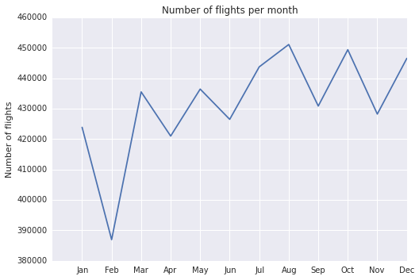

```python
tab=df.select('scheduled_departure_time', 'month').groupBy(df.month).count().orderBy('month', ascending=1).collect()
months=['Jan', 'Feb', 'Mar', 'Apr', 'May', 'Jun', 'Jul', 'Aug', 'Sep', 'Oct', 'Nov', 'Dec']

plt.plot(range(1,13),[tab[i][1] for i in range(len(tab))])
plt.title('Number of flights per month')
plt.ylabel('Number of flights')
plt.xticks(range(1,13),months)
```

**From the figure above we notice that August, October and December have the highest number of flights. This can be explained by the fact that August and December are holidays periods, and most summer holidays end in October**

### Question 3.2:

Is there any relationship between the number of flights and the days of the week? Plot a bar chart and interpret the figure.  
**NOTE:** You should study both global aggregates (irrespectively of the month of the year), and monthly aggregates (day statistics, for each different month of the year).  
By answering this question, we could learn about the importance of the weekend/weekday feature for our predictive task.

```
+-----------+------+
|day_of_week| count|
+-----------+------+
|          1|754636|
|          2|756532|
|          3|756864|
|          4|751537|
|          5|751531|
|          6|695245|
|          7|713703|
+-----------+------+
```

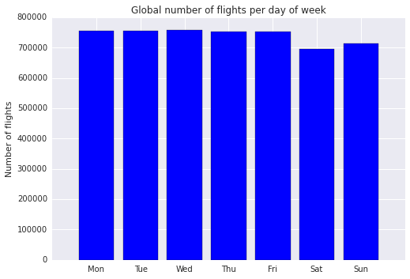

```python
t=df.select('scheduled_departure_time', 'day_of_week').groupBy(df.day_of_week).count().orderBy('day_of_week', ascending=1).collect()
df.select('scheduled_departure_time', 'day_of_week').groupBy(df.day_of_week).count().orderBy('day_of_week', ascending=1).show()
plt.bar(range(1,8),[t[i][1] for i in range(len(t))], color='blue', align='center')
days=['Mon','Tue','Wed','Thu','Fri','Sat','Sun']
plt.xticks(range(1,8),days)
plt.title('Global number of flights per day of week')
plt.ylabel('Number of flights')
```

**The figure shows that there are less flights in the weekends than in the working days from Monday to Friday. This can be due to the fact that people travel more for work than for pleasure. One more point is that flights on the weekends are generally more expensive.**

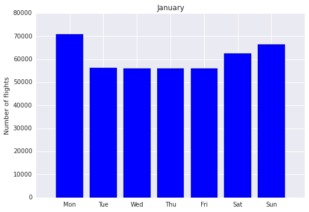

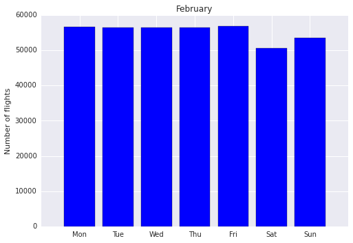

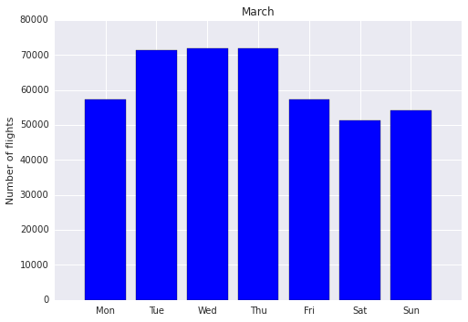

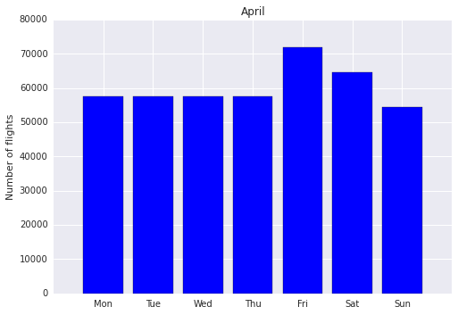

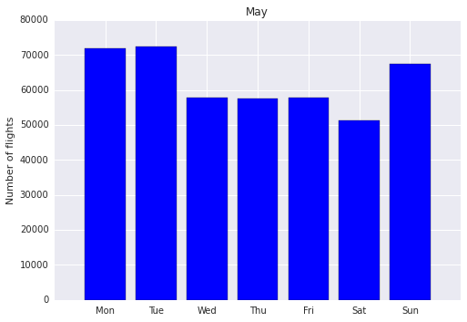

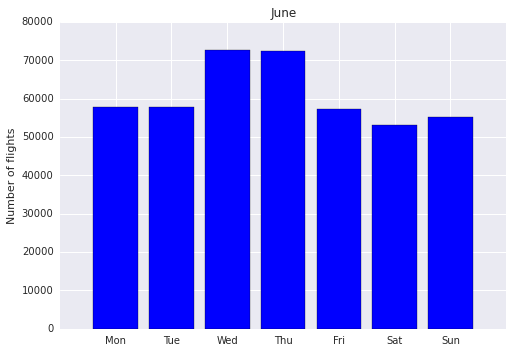

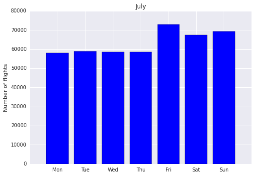

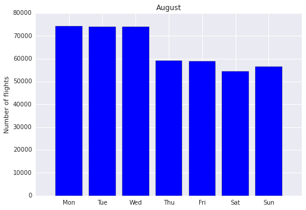

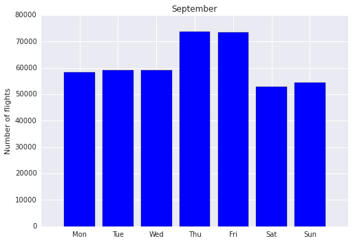

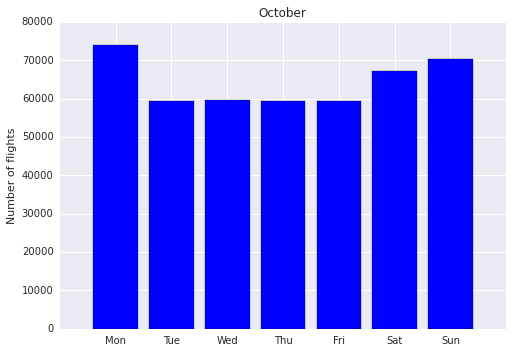

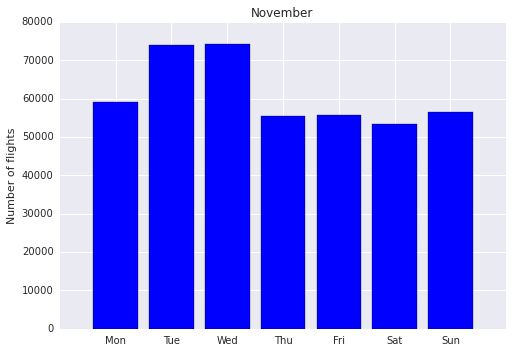

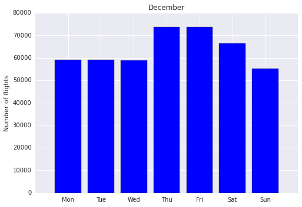

```python
T=df.select('scheduled_departure_time', 'day_of_week','month').groupBy(df.day_of_week,df.month).count().orderBy('month','day_of_week', ascending=1).collect()
#df.select('scheduled_departure_time', 'day_of_week','month').groupBy(df.day_of_week,df.month).count().orderBy('month','day_of_week', ascending=1).show()

months=['January', 'February', 'March', 'April', 'May', 'June', 'July', 'August', 'September', 'October', 'November', 'December']
for i in range (0, 84, 7):
    month_count=[T[j][2] for j in range(i,i+7)]
    plt.figure()
    plt.bar(range(1,8),month_count, color='blue', align='center')
    plt.title(months[i//7])
    plt.xticks(range(1,8),days)
    plt.ylabel('Number of flights')
```

**In the figures above, representing the number of flights per day of the week for each month, we notice that, in each month there are either two or three peaks, meaning that there are two or three days which have significatly more flights than the others. The explanation of that is due to the fact that in each month, each day is repeated 4 or 5 times. If it's a 30 days (respectively 31 days) month, then there are two days (respectively three days) which are repeated five times. So that exaplains the 2 or 3 peaks every month. On the other hand, february (1994) has 28 days, 4 times each one, we can see that its figure looks like the global one, where the weekends know less flights than the other days.**

### Question 3.3

How many flights in different days of months and in different hours of days?  
**NOTE:** Similarly to the previous note, you need to compute both global statistcs and monthly statistics.  
Plot bar charts, and interpret your figures.

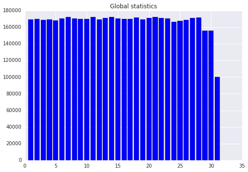

```python
n=df.select('scheduled_departure_time','day_of_month').groupBy(df.day_of_month).count().orderBy('day_of_month', ascending=1).collect()
days=range(1,32)
count=[k[1] for k in n]
plt.bar(days,count, color='blue', align='center')
plt.title('Global statistics')
```

**1994 was not a leap year, therefore the day 29 had only 11 occurences, as much as the day 30; that explains why there are almost the same number of flights in these days all over the year, and a bit less than all of the other days from 1 to 28. On the other hand, there are only 7 occurences of the day 31, that s why its number of flights in much lower.**

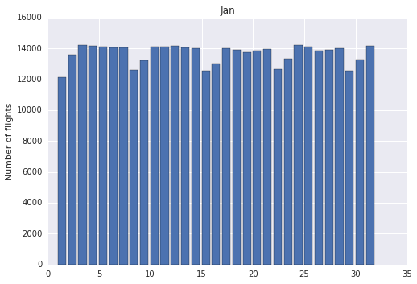

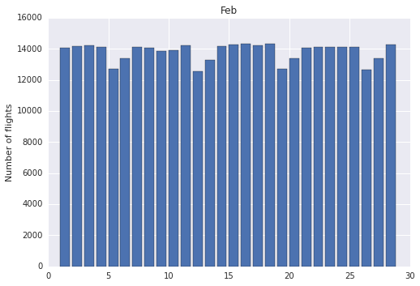

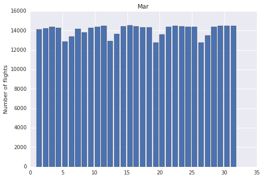

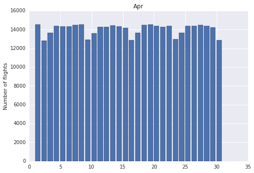

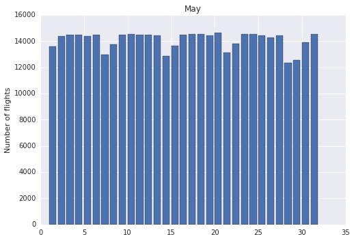

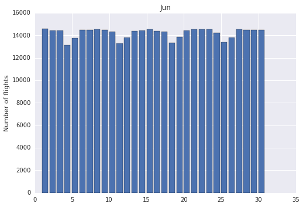

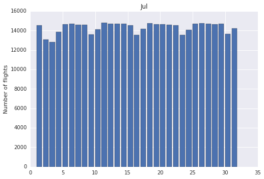

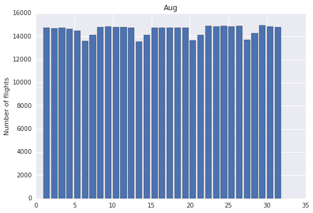

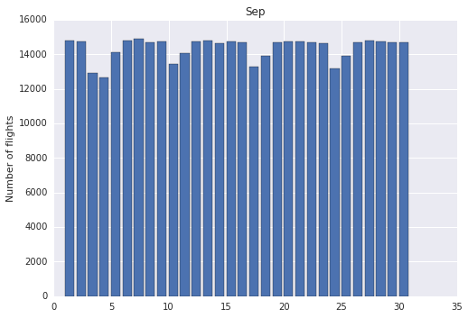

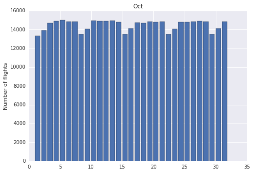

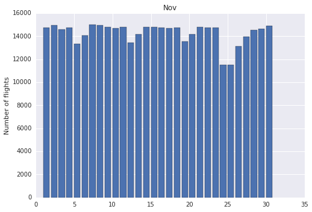

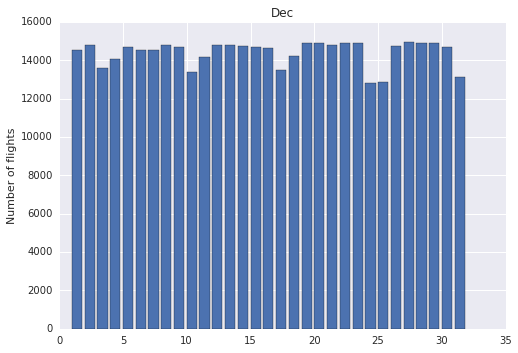

```python
n=df.select('scheduled_departure_time','day_of_month','month').groupBy(df.day_of_month,df.month).count().orderBy('month','day_of_month', ascending=1).collect()
k=0
months=['Jan','Feb','Mar','Apr','May','Jun','Jul','Aug','Sep','Oct','Nov','Dec']
for i in range(1,13):
    L=[]
    while k<len(n) and n[k][1]==i:
        L.append(n[k][2])
        k+=1
    plt.figure()
    plt.bar(range(1,len(L)+1),L)
    plt.title(months[i-1])
    plt.ylabel('Number of flights')
```

**The figures above, representing the number of flights for each day of every month, confirm and corroborate what we said before about the weekends having less flights than the other days. We can see that for every month there are five (almost) equal bars and then there are two minimas. Those minimas match the weekends.**

### Question 3.4

Which are the **top 20** busiest airports? Compute this in terms of the inbound, outbound and total number of flights.

```python
print( 'The top busiest airports in terms of number of flights are : ') ####10 unique carriers

src=df.groupBy(df.src_airport).count().selectExpr("src_airport as src","count as count1")
dest=df.groupBy(df.dest_airport).count().selectExpr("dest_airport as dest","count as count2")
dff=src.join(dest,src.src==dest.dest, 'inner')
busiest_airports = dff.withColumn('total', dff.count1 + dff.count2).selectExpr("dest as airport","total as total_flights").orderBy('total_flights',ascending=0)
busiest_airports.show()
```

```
The top busiest airports in terms of number of flights are :
+-------+-------------+
|airport|total_flights|
+-------+-------------+
|    ORD|       561461|
|    DFW|       516523|
|    ATL|       443074|
|    LAX|       306453|
|    STL|       304409|
|    DEN|       285526|
|    PHX|       280560|
|    DTW|       276272|
|    PIT|       262939|
|    CLT|       259712|
|    MSP|       247980|
|    SFO|       235478|
|    EWR|       233991|
|    IAH|       208591|
|    LGA|       203362|
|    BOS|       199696|
|    LAS|       189920|
|    PHL|       186897|
|    DCA|       176115|
|    MCO|       153720|
+-------+-------------+
only showing top 20 rows
```

### Question 3.5

Which are the **top 20** busiest carriers? Compute this in terms of number of flights.

```python
print( 'The top busiest carriers in terms of number of flights are : ') ####10 unique carriers
df.select('scheduled_departure_time', 'carrier').groupBy(df.carrier).count().orderBy('count', ascending=0).selectExpr("carrier as carrier","count as total_flights").show()
```

```
The top busiest carriers in terms of number of flights are :
+-------+-------------+
|carrier|total_flights|
+-------+-------------+
|     DL|       874526|
|     US|       857906|
|     AA|       722277|
|     UA|       638750|
|     WN|       565426|
|     CO|       484834|
|     NW|       482798|
|     TW|       258205|
|     HP|       177851|
|     AS|       117475|
+-------+-------------+
```

## Question 4

In this series of questions we focus on the computation of statistics about the percentage of delayed flights.

### Question 4.1

What is the percentage of delayed flights for different hours of the day? Plot a bar chart and interpret the figure.

IMPORTANT!

A flight is considered as delayed if it's actual arrival time is more than 15 minutes later than the scheduled arrival time.

```
<Container object of 1162 artists>
```

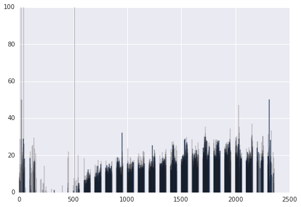

```python
delay0=df[df.arrival_delay>15].groupBy(df.scheduled_departure_time).count().orderBy('scheduled_departure_time',ascending=1).selectExpr("scheduled_departure_time as scheduled_departure_time","count as count1")
delay=delay0.collect()
total0=df.groupBy(df.scheduled_departure_time).count().orderBy('scheduled_departure_time',ascending=1).selectExpr("scheduled_departure_time as scheduled_departure_time0","count as count0")
total=total0.collect()
delay_pp=total0.join(delay0,total0.scheduled_departure_time0==delay0.scheduled_departure_time, 'inner')
delay_p=delay_pp.withColumn('Per', delay_pp.count1/ delay_pp.count0).selectExpr("scheduled_departure_time as scheduled_departure_time","Per as Per").orderBy("scheduled_departure_time")
L=[0 for k in range(len(total))]
for k,n in enumerate(total):
    for j in range(len(delay)):
        if delay[j][0]==n[0]: L[k]=(delay[j][1]/n[1])*100
times=[k[0] for k in total]
plt.bar(times,L)
```

**We notice that late night and early morning flights have less chances of having a delay. This might be explained by the fact that people tend to avoid traveling at those times. But, these statistics are not enough to have an idea of the delays in each hour, because it does not take into accout the duration of the delay which can change from 15 minutes to a few hours.**

### Question 4.2

You will realize that saying *"at 4 A.M. there is a very low chance of a flight being delayed"* is not giving you a full picture of the situation. Indeed, it might be true that there is very little probability for an early flight to be delayed, but if it does, the delay might be huge, like 6 hours!

Then, the question is: **which hours of the day are characterized by the largest mean delay?** (you can consider the median too) Plot a Bar chart and explain it.

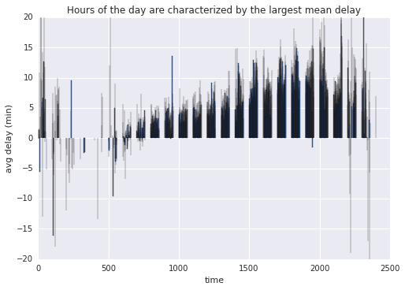

```python
mean_delay_per_hour=df.groupby('scheduled_departure_time').agg({"arrival_delay": "avg"}).orderBy("scheduled_departure_time", ascending=1)
L=mean_delay_per_hour.collect()

time=[k[0] for k in L]

avg=[]
for k in L:
    if k[1]=='null' or k[1]==None: avg.append(0)
    else: avg.append(k[1])

# print(avg[:50])
# print(time[:50])
plt.figure()


plt.bar(time,avg)
plt.title('Hours of the day are characterized by the largest mean delay')
plt.ylim(-20,20)
plt.ylabel('avg delay (min)')
plt.xlabel('time')
```

**The figure above shows that morning flights arrive in general earlier than scheduled. The delay problem begins at around 5am and goes up, accumulating, until the night.**

With data of year 1994, the flight from 3AM to 4AM often depart earlier than in their schedule. The flights in the morning have less delay then in the afternoon and evening.

So, an attentive student should notice here that we have somehow a problem with the definition of delay! Next, we will improve how to represent and visualize data to overcome this problem.

**NOTE**: the following piece of code assumes you correctly answered the previous questions. The naming convention of the DataFrames we use next should be clear enough for you to produce them by answering the questions above.

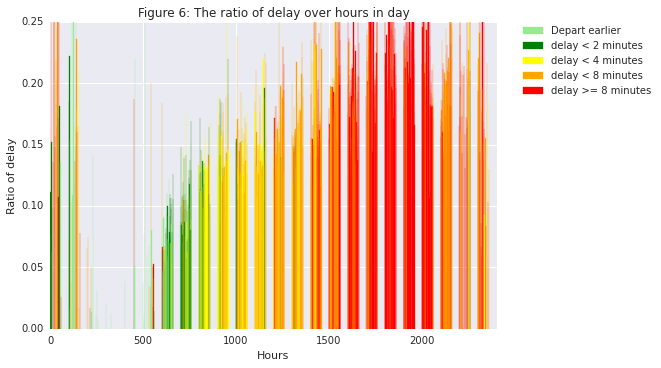

```python
pdf_mean_delay_per_hour = pd.DataFrame(data=mean_delay_per_hour.collect())
pdf_delay_ratio_per_hour=pd.DataFrame(data=delay_p.collect())
plt.xlabel("Hours")
plt.ylabel("Ratio of delay")
plt.title('Figure 6: The ratio of delay over hours in day')
plt.grid(True,which="both",ls="-")
bars = plt.bar(pdf_delay_ratio_per_hour[0], pdf_delay_ratio_per_hour[1], align='center', edgecolor = "black")
for i in range(0, len(bars)):
    color = 'red'
    if pdf_mean_delay_per_hour[1][i] < 0:
        color = 'lightgreen'
    elif pdf_mean_delay_per_hour[1][i] < 2:
        color = 'green'
    elif pdf_mean_delay_per_hour[1][i] < 4:
        color = 'yellow'
    elif pdf_mean_delay_per_hour[1][i] < 8:
        color = 'orange'

    bars[i].set_color(color)

patch1 = mpatches.Patch(color='lightgreen', label='Depart earlier')
patch2 = mpatches.Patch(color='green', label='delay < 2 minutes')
patch3 = mpatches.Patch(color='yellow', label='delay < 4 minutes')
patch4 = mpatches.Patch(color='orange', label='delay < 8 minutes')
patch5 = mpatches.Patch(color='red', label='delay >= 8 minutes')

plt.legend(handles=[patch1, patch2, patch3, patch4, patch5], bbox_to_anchor=(1.05, 1), loc=2, borderaxespad=0.)
plt.margins(0.05, 0)
plt.ylim(0,0.25)
plt.xlim(0,2400)
plt.show()
```

This example shows us that the way representing results are also important.

### Question 4.3

Plot a bar chart to show the percentage of delayed flights over days in a month. Discuss your findings from the figure.

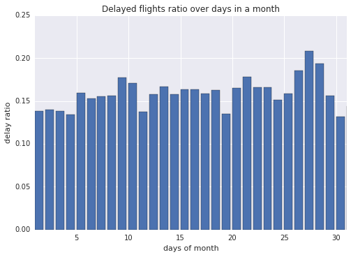

```python
delay=df[df.arrival_delay>15].groupBy(df.day_of_month).count().orderBy('day_of_month',ascending=1).collect()

total=df.groupBy(df.day_of_month).count().orderBy('day_of_month',ascending=1).collect()
L=[0 for k in range(len(total))]
for k,n in enumerate(total):
    for j in range(len(delay)):
        if delay[j][0]==n[0]: L[k]=(delay[j][1]/n[1])
days=[k[0] for k in total]
plt.bar(days,L)
plt.xlim(1,31)
plt.title('Delayed flights ratio over days in a month')
plt.xlabel('days of month')
plt.ylabel('delay ratio')
```

**The figure above shows that there are some days (26-28) with higher delays ratio than others, but we can't see any explanation to it, it might be just random. Maybe if we did the same analysis for a few years, it would help us have a reasonable conclusion.**